# Palmer Penguins

[TidyTuesday](https://github.com/rfordatascience/tidytuesday)

Akil Elkamel

7/28/2020

# The Data

The data this week comes from Dr. Kristen Gorman by way of the palmerpenguins R package by Dr. Kristen Gorman, Dr. Allison Horst, and Dr. Alison Hill.

Their palmerpenguins packagedown site and corresponding GitHub Repo has all the details, which I will duplicate some of below.

You can install their package for reproducible use via install.packages(“palmerpenguins”).

The goal of palmerpenguins is to provide a great dataset for data exploration & visualization, as an alternative to iris.

We gratefully acknowledge Palmer Station LTER and the US LTER Network. Special thanks to Marty Downs (Director, LTER Network Office) for help regarding the data license & use.

They’ve bundled both the raw data and the cleaned data together, which I have also included here.

The main measurements are body mass, culmen (bill) length, bill depth, and flipper length.

Get the data here

```r
# Get the Data

# Read in with tidytuesdayR package
# Install from CRAN via: install.packages("tidytuesdayR")
# This loads the readme and all the datasets for the week of interest

# Either ISO-8601 date or year/week works!

tuesdata <- tidytuesdayR::tt_load('2020-07-28')
tuesdata <- tidytuesdayR::tt_load(2020, week = 31)

penguins <- tuesdata$penguins

# Or read in the data manually

penguins.csv <- readr::read_csv('https://raw.githubusercontent.com/rfordatascience/tidytuesday/master/data/2020/2020-07-28/penguins.csv')

penguins_raw.csv <- readr::read_csv('https://raw.githubusercontent.com/rfordatascience/tidytuesday/master/data/2020/2020-07-28/penguins_raw.csv')
```

```r
library(palmerpenguins)
```

## Data Dictionary

**penguins.csv**

| variable | class | description |
| --- | --- | --- |
| species | integer | Penguin species (Adelie, Gentoo, Chinstrap) |
| island | integer | Island where recorded (Biscoe, Dream, Torgersen) |
| bill_length_mm | double | Bill length in millimeters (also known as culmen length) |
| bill_depth_mm | double | Bill depth in millimeters (also known as culmen depth) |
| flipper_length_mm | integer | Flipper length in mm |
| body_mass_g | integer | Body mass in grams |
| sex | integer | sex of the animal |
| year | integer | year recorded |

**penguins_raw.csv**

| variable | class | description |
| --- | --- | --- |
| studyName | character | Study name |
| Sample Number | double | Sample id |
| Species | character | Species of penguin |
| Region | character | Region where recorded |
| Island | character | Island where recorded |
| Stage | character | Stage of egg |
| Individual ID | character | Individual penguin ID |
| Clutch Completion | character | Egg clutch completion |
| Date Egg | double | Date of egg |
| Culmen Length (mm) | double | culmen length in mm (beak length) |
| Culmen Depth (mm) | double | culmen depth in mm (beak depth) |
| Flipper Length (mm) | double | Flipper length in mm |
| Body Mass (g) | double | Body mass in g |
| Sex | character | Sex of the penguin |
| Delta 15 N (o/oo) | double | Blood isotopic Nitrogen - used for dietary comparison |
| Delta 13 C (o/oo) | double | Blood isotopic Carbon - used for dietary comparison |
| Comments | character | Miscellaneous comments |

## Cleaning Script

No cleaning script today, feel free to work with the pre-cleaned data or try your hand at the raw data!

# Exploratory Data Analysis

## Dataset discovery

A first look to our data:

The dataset is composed by 344 observations (penguins) described by eight variables each. The varibales are presented previously in the table *penguins.csv*

```r
penguins %>%
    head()
```

```
## # A tibble: 6 x 8
##   species island bill_length_mm bill_depth_mm flipper_length_~ body_mass_g sex
##   <fct>   <fct>           <dbl>         <dbl>            <int>       <int> <fct>
## 1 Adelie  Torge~           39.1          18.7              181        3750 male
## 2 Adelie  Torge~           39.5          17.4              186        3800 fema~
## 3 Adelie  Torge~           40.3          18                195        3250 fema~
## 4 Adelie  Torge~           NA            NA                 NA          NA <NA>
## 5 Adelie  Torge~           36.7          19.3              193        3450 fema~
## 6 Adelie  Torge~           39.3          20.6              190        3650 male
## # ... with 1 more variable: year <int>
```

A summary of the data:

```r
penguins %>%
    summary()
```

```
##       species          island    bill_length_mm  bill_depth_mm
##  Adelie   :152   Biscoe   :168   Min.   :32.10   Min.   :13.10
##  Chinstrap: 68   Dream    :124   1st Qu.:39.23   1st Qu.:15.60
##  Gentoo   :124   Torgersen: 52   Median :44.45   Median :17.30
##                                  Mean   :43.92   Mean   :17.15
##                                  3rd Qu.:48.50   3rd Qu.:18.70
##                                  Max.   :59.60   Max.   :21.50
##                                  NA's   :2       NA's   :2
##  flipper_length_mm  body_mass_g       sex           year
##  Min.   :172.0     Min.   :2700   female:165   Min.   :2007
##  1st Qu.:190.0     1st Qu.:3550   male  :168   1st Qu.:2007
##  Median :197.0     Median :4050   NA's  : 11   Median :2008
##  Mean   :200.9     Mean   :4202                Mean   :2008
##  3rd Qu.:213.0     3rd Qu.:4750                3rd Qu.:2009
##  Max.   :231.0     Max.   :6300                Max.   :2009
##  NA's   :2         NA's   :2
```

We have three species of penguins distriuted as follow:

```r
penguins %>%
    count(species, sort = TRUE)
```

```
## # A tibble: 3 x 2
##   species       n
##   <fct>     <int>
## 1 Adelie      152
## 2 Gentoo      124
## 3 Chinstrap    68
```

Our penguins live in three islands

```r
penguins %>%
    count(island, sort = TRUE)
```

```
## # A tibble: 3 x 2
##   island        n
##   <fct>     <int>
## 1 Biscoe      168
## 2 Dream       124
## 3 Torgersen    52
```

We can see here that *Chinstrap* penguins live only in the *Dream* island, and the same thing for the *Gentoo* penguins which live only in the *Biscoe* island, while the *Adelie* penguins live in the three islands. We notice also that the *Torgerson* island contain only *Adelie* penguins.

```r
penguins %>%
    count(species, island)
```

```
## # A tibble: 5 x 3
##   species   island        n
##   <fct>     <fct>     <int>
## 1 Adelie    Biscoe       44
## 2 Adelie    Dream        56
## 3 Adelie    Torgersen    52
## 4 Chinstrap Dream        68
## 5 Gentoo    Biscoe      124
```

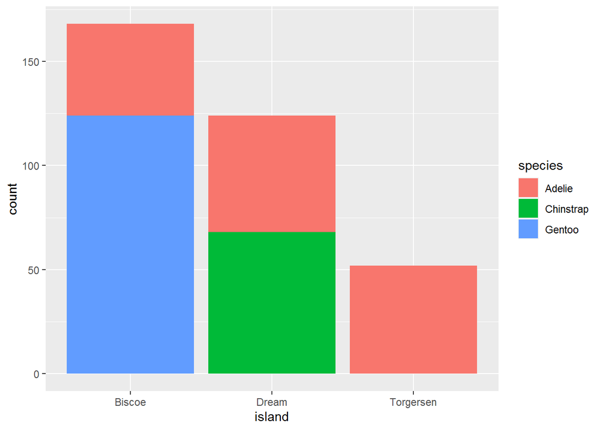

```r
penguins %>%
    ggplot(aes(island, fill = species)) +
    geom_bar()
```

## Data taming

```r
penguins <- penguins %>%
    mutate_if(is.character, factor)

penguins %>%
    summary()
```

```
##       species          island    bill_length_mm  bill_depth_mm
##  Adelie   :152   Biscoe   :168   Min.   :32.10   Min.   :13.10
##  Chinstrap: 68   Dream    :124   1st Qu.:39.23   1st Qu.:15.60
##  Gentoo   :124   Torgersen: 52   Median :44.45   Median :17.30
##                                  Mean   :43.92   Mean   :17.15
##                                  3rd Qu.:48.50   3rd Qu.:18.70
##                                  Max.   :59.60   Max.   :21.50
##                                  NA's   :2       NA's   :2
##  flipper_length_mm  body_mass_g       sex           year
##  Min.   :172.0     Min.   :2700   female:165   Min.   :2007
##  1st Qu.:190.0     1st Qu.:3550   male  :168   1st Qu.:2007
##  Median :197.0     Median :4050   NA's  : 11   Median :2008
##  Mean   :200.9     Mean   :4202                Mean   :2008
##  3rd Qu.:213.0     3rd Qu.:4750                3rd Qu.:2009
##  Max.   :231.0     Max.   :6300                Max.   :2009
##  NA's   :2         NA's   :2
```

## Missing data

We see that we have 11 observations without sex value, among of them two observations are missing also *bill_length_mm*, *bill_depth_mm*, *flipper_length_mm*, and *body_mass_g*.

```r
penguins %>%
    is.na() %>%
    colSums()
```

```
##           species            island    bill_length_mm     bill_depth_mm
##                 0                 0                 2                 2
## flipper_length_mm       body_mass_g               sex              year
##                 2                 2                11                 0
```

```r
# Load the VIM package
library(VIM)
```

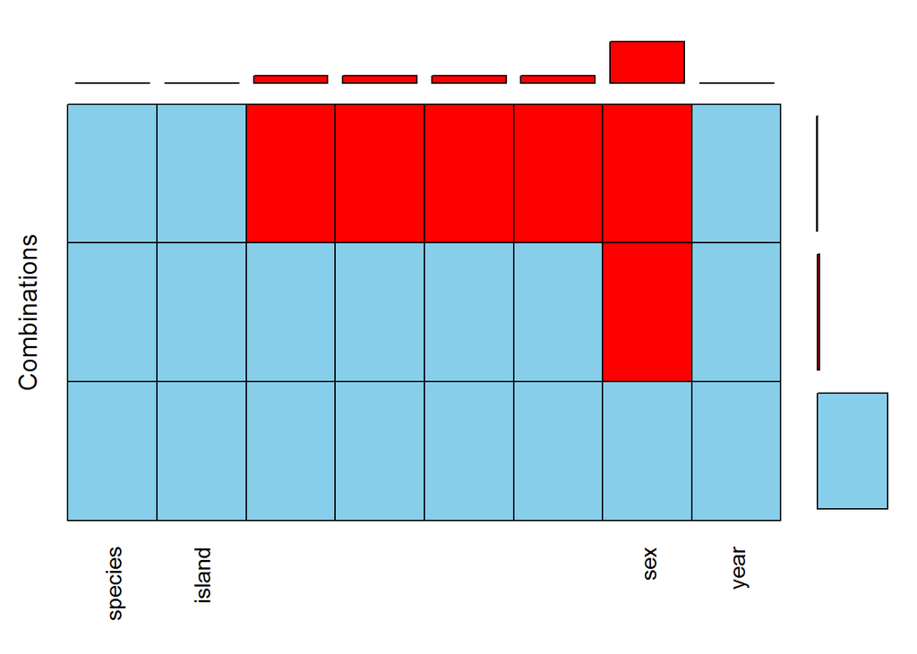

```r
# Draw an aggregation plot of biopics
penguins %>%
    aggr(combined = TRUE, numbers = TRUE)
```

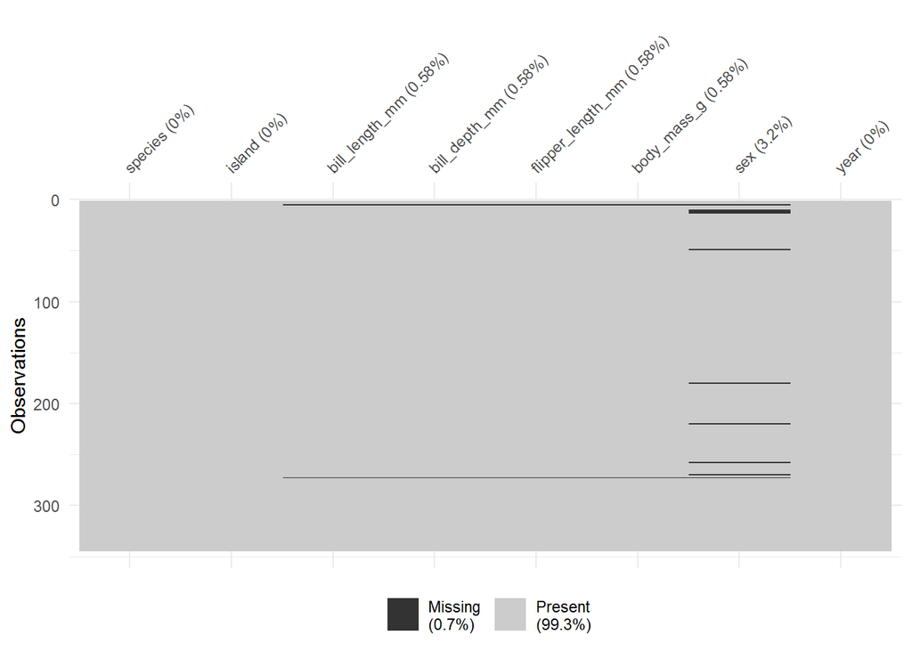

```r
library(visdat)
penguins %>%
    vis_miss()
```

```r
penguins %>%
    filter(is.na(sex))
```

```
## # A tibble: 11 x 8
##    species island bill_length_mm bill_depth_mm flipper_length_~ body_mass_g
##    <fct>   <fct>           <dbl>         <dbl>            <int>       <int>
##  1 Adelie  Torge~           NA            NA                 NA          NA
##  2 Adelie  Torge~           34.1          18.1              193        3475
##  3 Adelie  Torge~           42            20.2              190        4250
##  4 Adelie  Torge~           37.8          17.1              186        3300
##  5 Adelie  Torge~           37.8          17.3              180        3700
##  6 Adelie  Dream            37.5          18.9              179        2975
##  7 Gentoo  Biscoe           44.5          14.3              216        4100
##  8 Gentoo  Biscoe           46.2          14.4              214        4650
##  9 Gentoo  Biscoe           47.3          13.8              216        4725
## 10 Gentoo  Biscoe           44.5          15.7              217        4875
## 11 Gentoo  Biscoe           NA            NA                 NA          NA
## # ... with 2 more variables: sex <fct>, year <int>
```

In the following we will use penguins without missing data.

```r
penguins <- penguins%>%
    filter(!is.na(sex))
```

## Data imputation

```r
library(missForest)

penguins <- penguins %>%
    mutate(sex_na = is.na(sex))

penguins <- as.data.frame(penguins)

imp_res <- missForest(penguins)

imp_err <- imp_res$OOBerror
print(imp_err)

# Pair-wise technique

imp_res <- missForest(penguins, variablewise = TRUE)

per_variable_errors <- imp_res$OOBerror
print(per_variable_errors)

names(per_variable_errors) <- paste(names(penguins),
                                    names(per_variable_errors),
                                    sep = "_")

# Print the renamed errors
print(per_variable_errors)

imp_res
```

# Visual exploration

A first visual exploration that shows the distribution of penguins according to “*bill_depth_mm*” vs “*bill_length_mm*”.

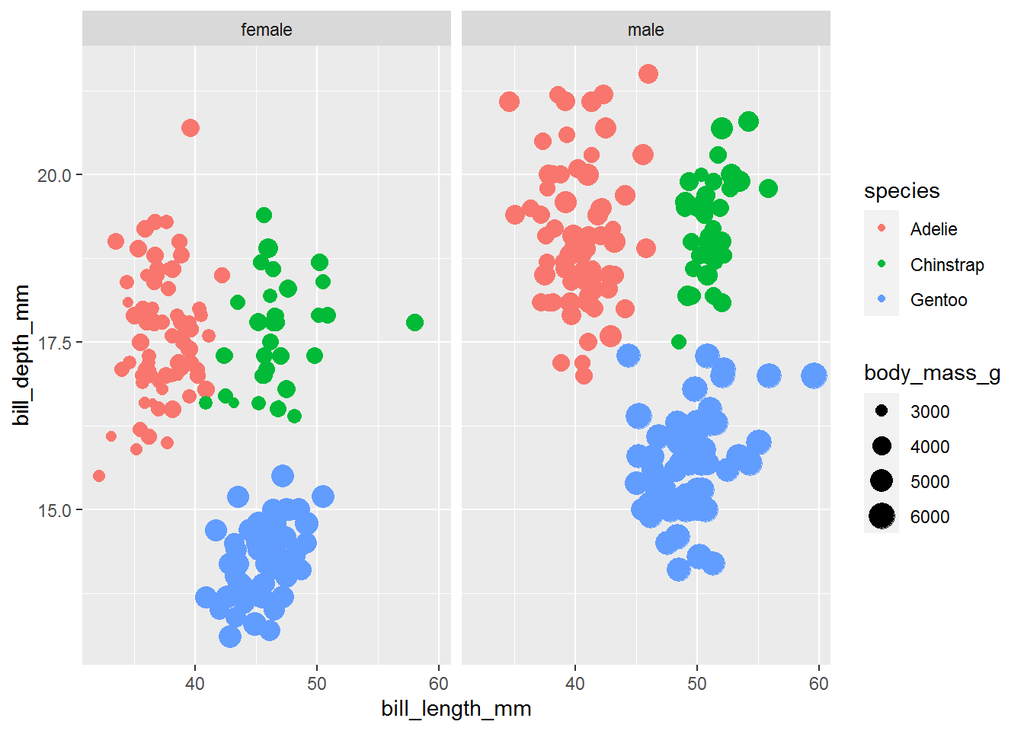

```r
penguins %>%
    filter(!is.na(sex)) %>%
    ggplot(aes(x = bill_length_mm, y = bill_depth_mm, col = species, size = body_mass_g)) +
        geom_point() +
        facet_wrap(~ sex)
```

A histogram plot of the diffirent measures taht characterize penguins.

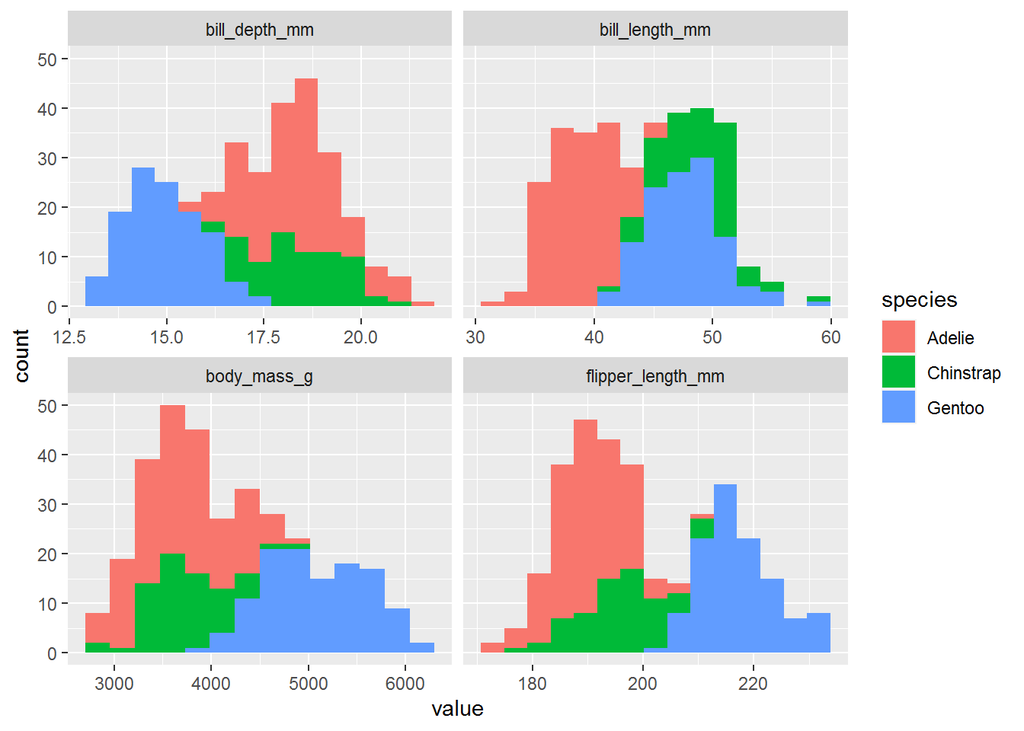

```r
penguins %>%
    pivot_longer(bill_length_mm:body_mass_g,
                 names_to = "measure",
                 values_to = "value") %>%
    ggplot(aes(x = value, fill = species)) +
    geom_histogram(bins = 15) +
    facet_wrap(~ measure, scales = "free_x")
```

And here is the distribution of the diffirent mesures:

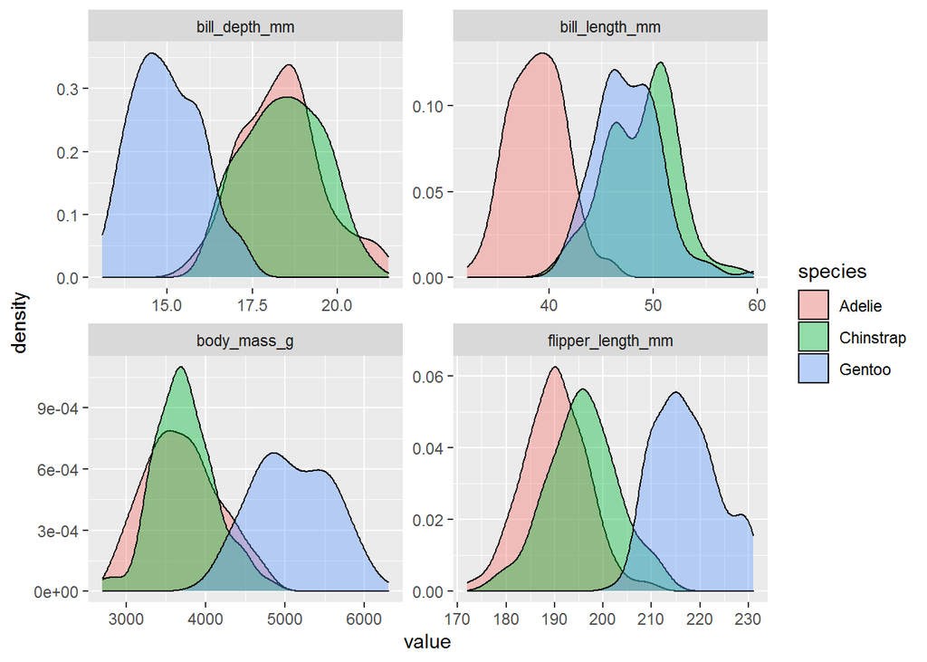

```r
penguins %>%
    pivot_longer(bill_length_mm:body_mass_g,
                 names_to = "measure",
                 values_to = "value") %>%
    ggplot(aes(x = value, fill = species)) +
    geom_density(alpha = 0.4) +
    facet_wrap(~ measure, scales = "free")
```

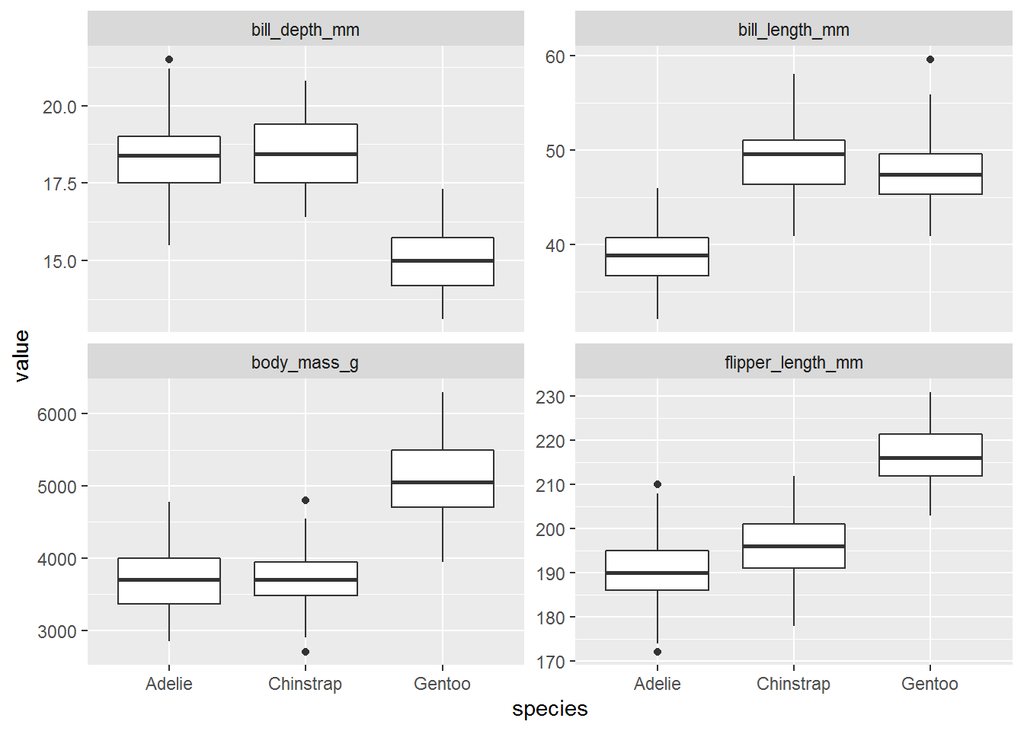

```r
penguins %>%
    pivot_longer(bill_length_mm:body_mass_g,
                 names_to = "measure",
                 values_to = "value") %>%
    ggplot(aes(x = species, y = value)) +
    geom_boxplot() +
    facet_wrap(~ measure, scales = "free_y")
```

# Modeling

We will use in this step `tidymodels`.

```r
library(tidymodels)
```

We minimize our dataset to get only necessary columns:

```r
penguins <- penguins %>%
  select(species, bill_length_mm:body_mass_g)
```

## Train / Test data slit

```r
train_test_split <- penguins %>%
  initial_split(prop = 4/5, strata = species)

penguins_train <- training(train_test_split)
penguins_test <- testing(train_test_split)
```

## Evaluation metrics

```r
ev_metrics <- metric_set(accuracy, kap, roc_auc)
```

```r
models_res <- testing(train_test_split) %>%
  select(actual = species)
```

## Multinomial Regression Model

```r
multinom_reg_clf <- multinom_reg(mode = "classification", penalty = 0) %>%
  set_engine("glmnet") %>%
  fit(formula = species ~ bill_length_mm + bill_depth_mm + flipper_length_mm + body_mass_g,
      data = training(train_test_split))

pred <- testing(train_test_split) %>%
  predict(multinom_reg_clf, new_data = .)

models_res <- models_res %>%
  bind_cols(pred) %>%
  rename(multinom_reg = .pred_class)
```

## K Nearest Neighbors

```r
knn_clf <- nearest_neighbor(mode = "classification",
                            neighbors = 13) %>%
  set_engine("kknn") %>%
  fit(formula = species ~ bill_length_mm + bill_depth_mm + flipper_length_mm + body_mass_g,
      data = training(train_test_split))

pred <- testing(train_test_split) %>%
  predict(knn_clf, new_data = .)

models_res <- models_res %>%
  bind_cols(pred) %>%
  rename(knn = .pred_class)
```

## Support Vector Machine

```r
svm_clf <- svm_poly(mode = "classification") %>%
  set_engine("kernlab") %>%
  fit(formula = species ~ bill_length_mm + bill_depth_mm + flipper_length_mm + body_mass_g,
      data = training(train_test_split))
pred <- testing(train_test_split) %>%
  predict(svm_clf, new_data = .)

models_res <- models_res %>%
  bind_cols(pred) %>%
  rename(svm = .pred_class)
```

## Decision Tree

```r
dt_clf <- decision_tree(mode = "classification") %>%
  set_engine("rpart") %>%
  fit(formula = species ~ bill_length_mm + bill_depth_mm + flipper_length_mm + body_mass_g,
      data = training(train_test_split))

pred <- testing(train_test_split) %>%
  predict(dt_clf, new_data = .)

models_res <- models_res %>%
  bind_cols(pred) %>%
  rename(dt = .pred_class)
```

## Random Forest

```r
rf_clf <- rand_forest(mode = "classification") %>%
  set_engine("ranger") %>%
  fit(formula = species ~ bill_length_mm + bill_depth_mm + flipper_length_mm + body_mass_g,
      data = training(train_test_split))

pred <- testing(train_test_split) %>%
  predict(rf_clf, new_data = .)

models_res <- models_res %>%
  bind_cols(pred) %>%
  rename(rf = .pred_class)
```

```r
models_res
```

```
## # A tibble: 65 x 6
##    actual multinom_reg knn    svm    dt        rf
##    <fct>  <fct>        <fct>  <fct>  <fct>     <fct>
##  1 Adelie Adelie       Adelie Adelie Adelie    Adelie
##  2 Adelie Adelie       Adelie Adelie Adelie    Adelie
##  3 Adelie Adelie       Adelie Adelie Adelie    Adelie
##  4 Adelie Adelie       Adelie Adelie Adelie    Adelie
##  5 Adelie Adelie       Adelie Adelie Adelie    Adelie
##  6 Adelie Adelie       Adelie Adelie Chinstrap Adelie
##  7 Adelie Adelie       Adelie Adelie Adelie    Adelie
##  8 Adelie Adelie       Adelie Adelie Adelie    Adelie
##  9 Adelie Adelie       Adelie Adelie Adelie    Adelie
## 10 Adelie Adelie       Adelie Adelie Adelie    Adelie
## # ... with 55 more rows
```

```r
table(models_res$actual, models_res$multinom_reg)
```

```
##
##             Adelie Chinstrap Gentoo
##   Adelie        29         0      0
##   Chinstrap      0        13      0
##   Gentoo         1         0     22
```

```r
table(models_res$actual, models_res$knn)
```

```
##
##             Adelie Chinstrap Gentoo
##   Adelie        29         0      0
##   Chinstrap      1        12      0
##   Gentoo         0         0     23
```

```r
table(models_res$actual, models_res$svm)
```

```
##
##             Adelie Chinstrap Gentoo
##   Adelie        29         0      0
##   Chinstrap      1        12      0
##   Gentoo         0         0     23
```

```r
table(models_res$actual, models_res$dt)
```

```
##
##             Adelie Chinstrap Gentoo
##   Adelie        28         1      0
##   Chinstrap      1        12      0
##   Gentoo         0         0     23
```

```r
table(models_res$actual, models_res$rf)
```

```
##
##             Adelie Chinstrap Gentoo
##   Adelie        29         0      0
##   Chinstrap      1        12      0
##   Gentoo         0         0     23
```

## Advanced

### Bootstrap

```r
set.seed(1234)
penguins_boot <- bootstraps(penguins_train, strata = species)
```

### Workflow

```r
penguins_wf <- workflow() %>%
  add_formula(species ~ .)

penguins_wf
```

```
## == Workflow =========================================================
## Preprocessor: Formula
## Model: None
##
## -- Preprocessor -----------------------------------------------------
## species ~ .
```

### Add models to a workflow

We define here some models specifications:

- KNN
- Random Forest

```r
knn_spec <- nearest_neighbor() %>%
  set_mode("classification") %>%
  set_engine("kknn")

rf_spec <- rand_forest() %>%
  set_mode("classification") %>%
  set_engine("ranger")
```

```r
knn_rs <- penguins_wf %>%
  add_model(knn_spec) %>%
  fit_resamples(
    resamples = penguins_boot,
    control = control_resamples(
      save_pred = TRUE,
      verbose = TRUE
    )
  )
```

[output not shown]

[output not shown]

[output not shown]

[output not shown]

[output not shown]

[output not shown]

[output not shown]

[output not shown]

[output not shown]

[output not shown]

[output not shown]

[output not shown]

[output not shown]

[output not shown]

[output not shown]

[output not shown]

[output not shown]

[output not shown]

[output not shown]

[output not shown]

[output not shown]

[output not shown]

[output not shown]

[output not shown]

[output not shown]

[output not shown]

[output not shown]

[output not shown]

[output not shown]

[output not shown]

[output not shown]

[output not shown]

[output not shown]

[output not shown]

[output not shown]

[output not shown]

[output not shown]

[output not shown]

[output not shown]

[output not shown]

[output not shown]

[output not shown]

[output not shown]

[output not shown]

[output not shown]

[output not shown]

[output not shown]

[output not shown]

[output not shown]

[output not shown]

[output not shown]

[output not shown]

[output not shown]

[output not shown]

[output not shown]

[output not shown]

[output not shown]

[output not shown]

[output not shown]

[output not shown]

[output not shown]

[output not shown]

[output not shown]

[output not shown]

[output not shown]

[output not shown]

[output not shown]

[output not shown]

[output not shown]

[output not shown]

[output not shown]

[output not shown]

[output not shown]

[output not shown]

[output not shown]

[output not shown]

[output not shown]

[output not shown]

[output not shown]

[output not shown]

[output not shown]

[output not shown]

[output not shown]

[output not shown]

[output not shown]

[output not shown]

[output not shown]

[output not shown]

[output not shown]

[output not shown]

[output not shown]

[output not shown]

[output not shown]

[output not shown]

[output not shown]

[output not shown]

[output not shown]

[output not shown]

[output not shown]

[output not shown]

[output not shown]

[output not shown]

[output not shown]

[output not shown]

[output not shown]

[output not shown]

[output not shown]

[output not shown]

[output not shown]

[output not shown]

[output not shown]

[output not shown]

[output not shown]

[output not shown]

[output not shown]

[output not shown]

[output not shown]

[output not shown]

[output not shown]

[output not shown]

[output not shown]

[output not shown]

[output not shown]

[output not shown]

[output not shown]

```r
rf_rs <- penguins_wf %>% add_model(rf_spec) %>%
  fit_resamples(
    resamples = penguins_boot,
    control = control_resamples(
      save_pred = TRUE,
      verbose = TRUE
    )
  )
```

[output not shown]

[output not shown]

[output not shown]

[output not shown]

[output not shown]

[output not shown]

[output not shown]

[output not shown]

[output not shown]

[output not shown]

[output not shown]

[output not shown]

[output not shown]

[output not shown]

[output not shown]

[output not shown]

[output not shown]

[output not shown]

[output not shown]

[output not shown]

[output not shown]

[output not shown]

[output not shown]

[output not shown]

[output not shown]

[output not shown]

[output not shown]

[output not shown]

[output not shown]

[output not shown]

[output not shown]

[output not shown]

[output not shown]

[output not shown]

[output not shown]

[output not shown]

[output not shown]

[output not shown]

[output not shown]

[output not shown]

[output not shown]

[output not shown]

[output not shown]

[output not shown]

[output not shown]

[output not shown]

[output not shown]

[output not shown]

[output not shown]

[output not shown]

[output not shown]

[output not shown]

[output not shown]

[output not shown]

[output not shown]

[output not shown]

[output not shown]

[output not shown]

[output not shown]

[output not shown]

[output not shown]

[output not shown]

[output not shown]

[output not shown]

[output not shown]

[output not shown]

[output not shown]

[output not shown]

[output not shown]

[output not shown]

[output not shown]

[output not shown]

[output not shown]

[output not shown]

[output not shown]

[output not shown]

[output not shown]

[output not shown]

[output not shown]

[output not shown]

[output not shown]

[output not shown]

[output not shown]

[output not shown]

[output not shown]

[output not shown]

[output not shown]

[output not shown]

[output not shown]

[output not shown]

[output not shown]

[output not shown]

[output not shown]

[output not shown]

[output not shown]

[output not shown]

[output not shown]

[output not shown]

[output not shown]

[output not shown]

[output not shown]

[output not shown]

[output not shown]

[output not shown]

[output not shown]

[output not shown]

[output not shown]

[output not shown]

[output not shown]

[output not shown]

[output not shown]

[output not shown]

[output not shown]

[output not shown]

[output not shown]

[output not shown]

[output not shown]

[output not shown]

[output not shown]

[output not shown]

[output not shown]

[output not shown]

[output not shown]

[output not shown]

[output not shown]

### Evaluate models

```r
collect_metrics(knn_rs)
```

```
## # A tibble: 2 x 5
##   .metric  .estimator  mean     n std_err
##   <chr>    <chr>      <dbl> <int>   <dbl>
## 1 accuracy multiclass 0.979    25 0.00262
## 2 roc_auc  hand_till  0.996    25 0.00112
```

```r
collect_metrics(rf_rs)
```

```
## # A tibble: 2 x 5
##   .metric  .estimator  mean     n  std_err
##   <chr>    <chr>      <dbl> <int>    <dbl>
## 1 accuracy multiclass 0.961    25 0.00301
## 2 roc_auc  hand_till  0.995    25 0.000995
```

```r
knn_rs %>%
  conf_mat_resampled()
```

```
## # A tibble: 9 x 3
##   Prediction Truth      Freq
##   <fct>      <fct>     <dbl>
## 1 Adelie     Adelie    42.7
## 2 Adelie     Chinstrap  1.6
## 3 Adelie     Gentoo     0
## 4 Chinstrap  Adelie     0.48
## 5 Chinstrap  Chinstrap 18.8
## 6 Chinstrap  Gentoo     0
## 7 Gentoo     Adelie     0
## 8 Gentoo     Chinstrap  0
## 9 Gentoo     Gentoo    35.4
```

### ROC-AUC

With autoplot

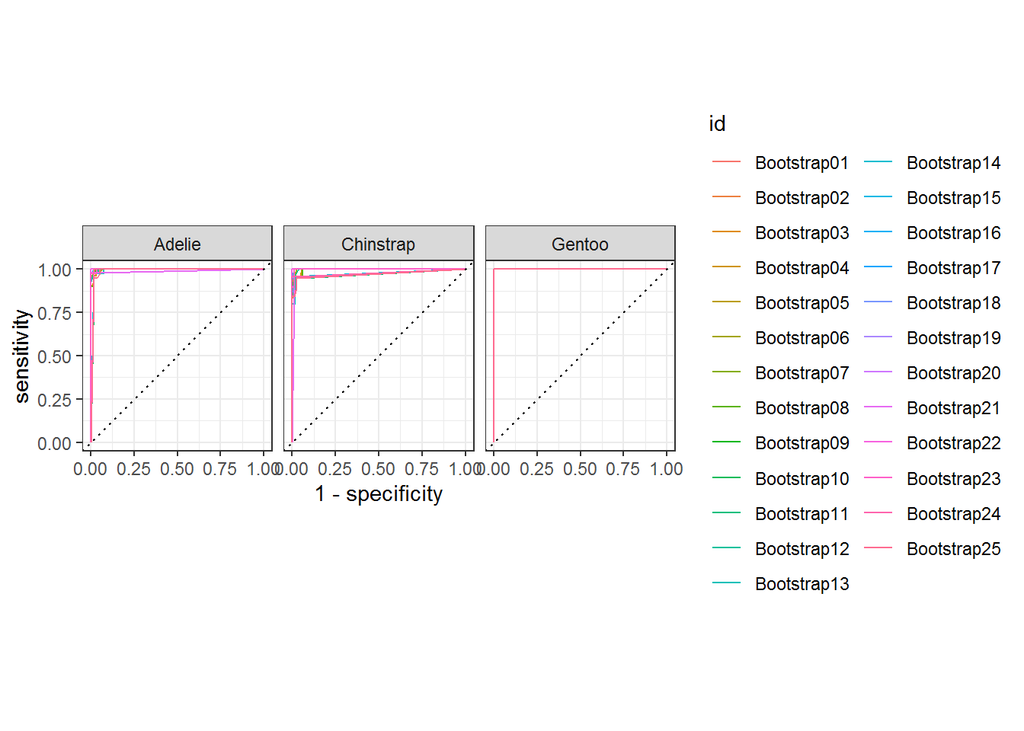

```r
knn_rs %>%
  collect_predictions() %>%
  group_by(id) %>%
  roc_curve(species, .pred_Adelie:.pred_Gentoo) %>%
  autoplot()
```

Manually with ggplot

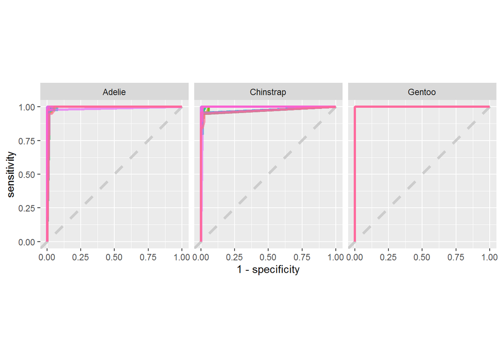

```r
knn_rs %>%
  collect_predictions() %>%
  group_by(id) %>%
  roc_curve(species, .pred_Adelie:.pred_Gentoo) %>%
  ggplot(aes(1-specificity, sensitivity, color = id)) +
  geom_abline(lty = 2, color = "gray80", size = 1.25) +
  geom_path(show.legend = FALSE, alpha = 0.7, size = 1.2) +
  coord_equal() +
  facet_wrap(~ .level)
```

## Cross-Validation

```r
penguins_train_cv <- penguins_train %>%
  rsample::vfold_cv(strata = species)

rf <- rand_forest() %>%
  set_mode("classification") %>%
  set_engine("randomForest")
```

```r
wf <- workflow() %>%
  add_formula(species ~ .)

res <- wf %>%
  add_model(rf) %>%
  fit_resamples(
    resamples = penguins_train_cv,
    metrics = metric_set(accuracy, kap, roc_auc)
  )

res %>%
  collect_metrics()
```

```
## # A tibble: 3 x 5
##   .metric  .estimator  mean     n std_err
##   <chr>    <chr>      <dbl> <int>   <dbl>
## 1 accuracy multiclass 0.970    10 0.00730
## 2 kap      multiclass 0.953    10 0.0113
## 3 roc_auc  hand_till  0.997    10 0.00106
```

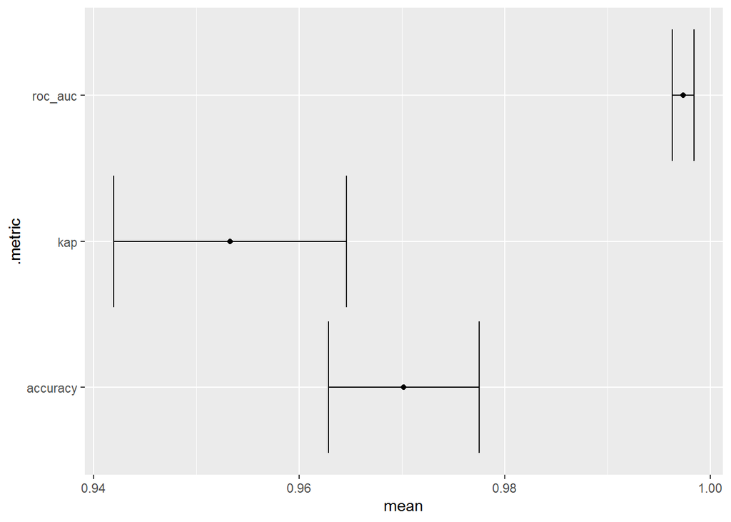

```r
res %>%
  collect_metrics() %>%
  ggplot(aes(mean, .metric)) +
  geom_point() +
  geom_errorbarh(aes(xmin = mean - std_err,
                     xmax = mean + std_err))
```